[figure not shown]

WI-428

Bulkhead Wiring Harness (In Engine Compartment) LH

WIRING SYSTEM

63.Bulkhead Wiring Harness (In Engine Compartment) LH

A: LOCATION

1. ENGINE TYPE FA

Connector Connecting to

No. Pole Color Area No. Description

AB13 2 Y C-2 Front sub sensor LH

B8 5 GR A-4 Front wiper motor

B9 2 B C-3 Battery sensor

B10 4 GR C-3 Pressure switch

B15 2 GR B-3 Front ABS wheel speed sensor LH

B16 2 GR B-3 Brake fluid level switch

B143 20 B-3

B145 7 BR B-3

B146 2 B D-3 Front washer motor

B186 8 B-3 M/B

B360 16 GR B-3 F109

Through joint connector

B361 14 GR B-3 F108

B396 2 BR C-3 Washer fluid level sensor

B564 17 B-3 Relay holder

B565 3 B B-3 Brake booster pressure sensor

B571 2 B-3 M/B

: White or natural color

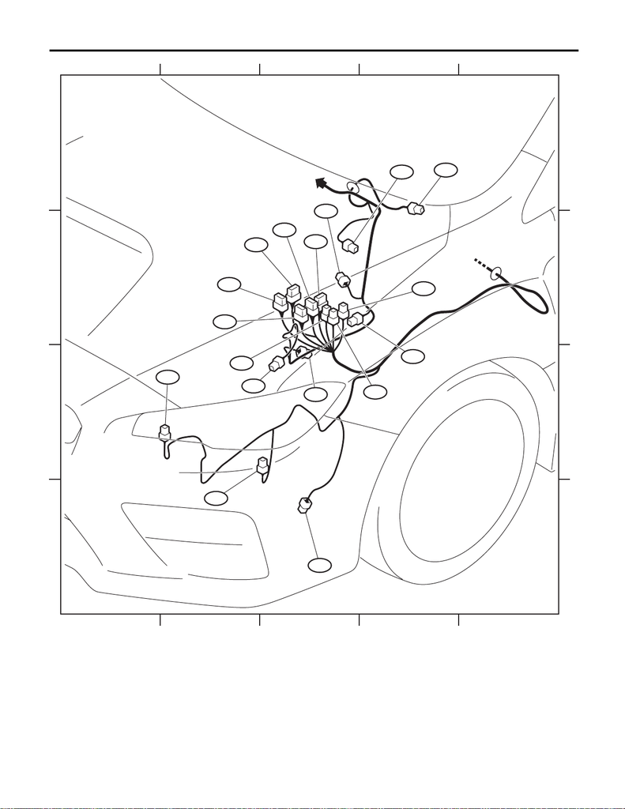

WI-429

Bulkhead Wiring Harness (In Engine Compartment) LH

WIRING SYSTEM

WI-44613

12345

12345

A

B

C

D

A

B

C

D

RH

B144

B9

B360

B16

B145

B15

B186

B10

AB13

B146

B571

B565

B8

B564

B361

B143

B396

[figure not shown]

WI-430

Bulkhead Wiring Harness (In Engine Compartment) LH

WIRING SYSTEM

2. ENGINE TYPE EJ

Connector Connecting to

No. Pole Color Area No. Description

AB13 2 Y C-2 Front sub sensor LH

B8 5 GR A-4 Front wiper motor

B10 4 GR C-3 Pressure switch

B15 2 GR B-3 Front ABS wheel speed sensor LH

B16 2 GR B-3 Brake fluid level switch

B143 20 B-3

B145 7 BR B-3

B146 2 B D-3 Front washer motor

B186 8 B-3 M/B

B360 16 GR B-3 F109

Through joint connector

B361 14 GR B-3 F108

B396 2 BR C-3 Washer fluid level sensor

B571 2 B-3 M/B

: White or natural color

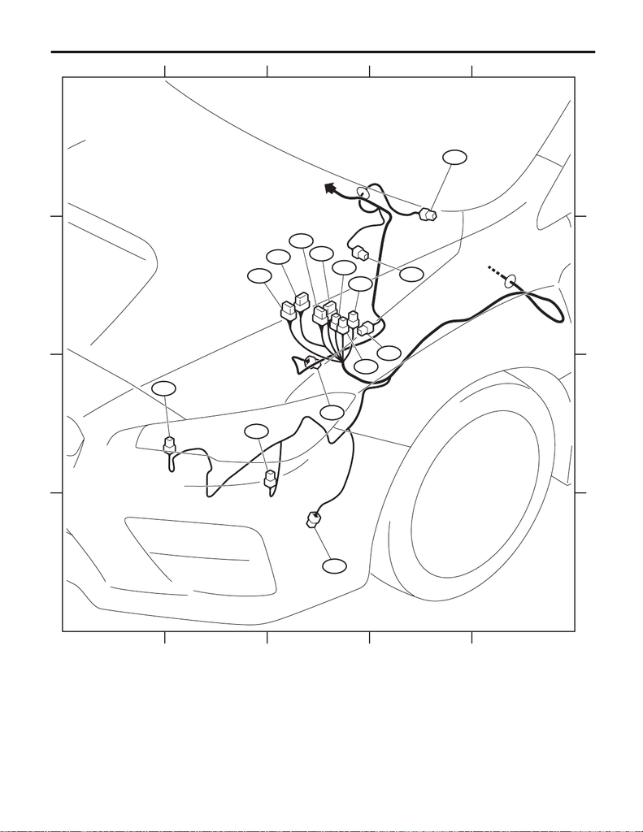

WI-431

Bulkhead Wiring Harness (In Engine Compartment) LH

WIRING SYSTEM

WI-44615

12345

12345

A

B

C

D

A

B

C

D

RH

B396

AB13

B146

B361

B143

B360

B144

B571

B145

B10

B186

B15

B16

B8